# L’estimateur Chao1

23 January 2021

## Introduction

## Problématique

Estimer la richesse (le nombre d’espèces) d’un système hyperdivers comme une communauté en forêt tropicale est difficile.

Beaucoup d’espèces sont rares donc un échantillonnage aléatoire (inventaire) de taille raisonnable ne permet pas de les observer.

Des estimateurs de la richesse ont été développés pour estimer la richesse réelle à partir d’un inventaire incomplet.

## Illustration

Inventaire d’une parcelle de Paracou, Sinamary, Guyane

Nombre d’espèces observées : 334.

Espèce la plus abondante (wapa : \(Eperua falcata\)) : 266 individus.

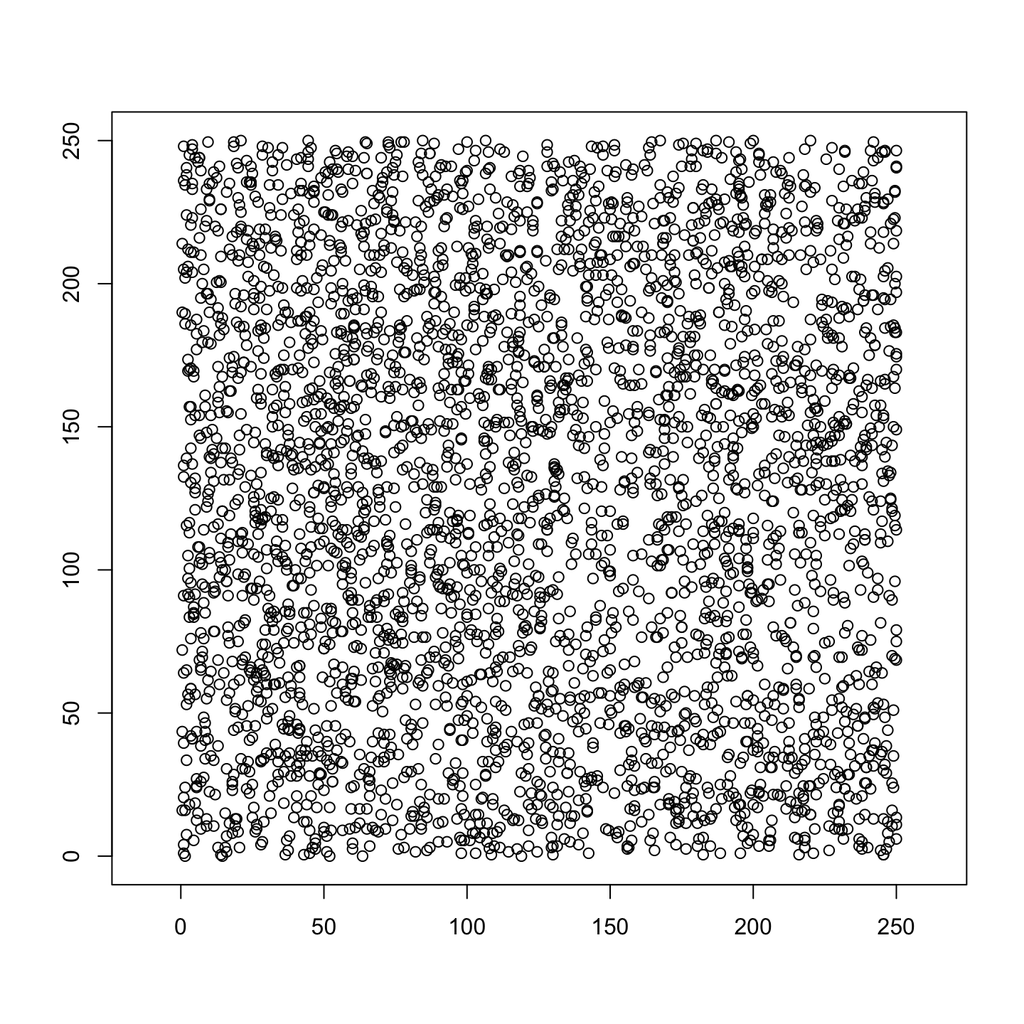

https://paracou.cirad.fr

## Illustration

La parcelle est un échantillon de la communauté forestière locale.

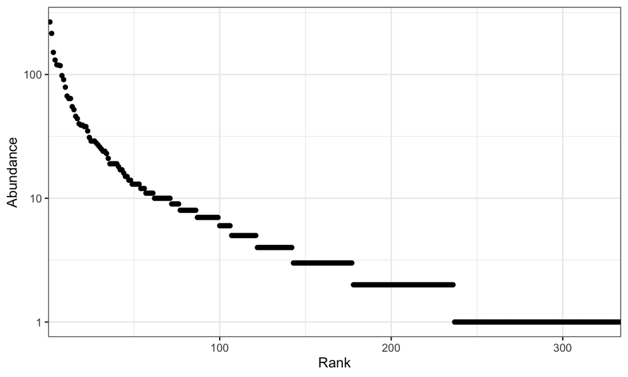

Question : combien y a-t-il d’espèces d’arbres dans cette communauté ?

## Courbe d’accumulation

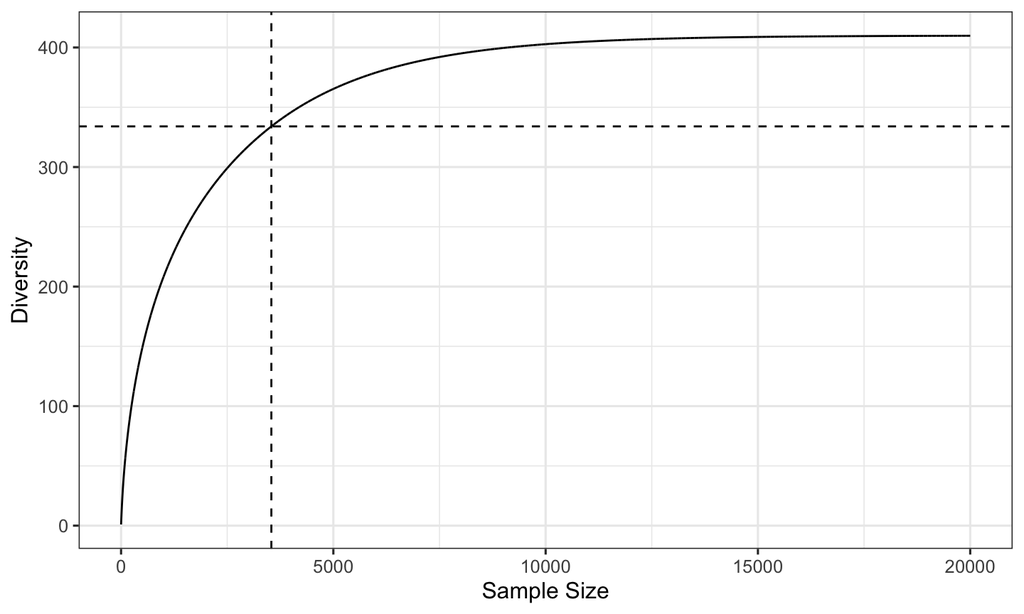

Espérance du nombre d’espèces échantillonnées en fonction de la taille de l’inventaire.

## Estimateur Chao1

Développé par Anne Chao (Chao 2004).

Premier estimateur utilisé largement par les écologues, bon support mathématique.

Intuition :

- les espèces observées une fois auraient pu ne pas l’être.
- lien (à établir) entre les espèces observées un petit nombre de fois et les espèces manquées.

## Construction de l’estimateur

## Notations

Un inventaire de \(n\) individus tirés indépendamment et aléatoirement est réalisé dans une communauté.

Les individus appartiennent à l’espèce \(s\) avec la probabilité \(p_s\), \(\sum_1^S{p_s}=1\).

L’inventaire manque quelques espèces parmi les moins fréquentes : seules \(s_{obs}\) espèces sont observées.

\({s}_{n}^{\nu}\) est le nombre d’espèces observées \(\nu\) fois dans un échantillon de taille \(n\). C’est une réalisation de la variable aléatoire \({S}_{n}^{\nu}\).

## Observer une espèce

La probabilité qu’un individu inventorié ne soit pas de l’espèce \(s\) est

\[1-p_s\]

La probabilité de ne pas inclure l’espèce \(s\) dans l’inventaire est

\[(1-p_s)^n\]

La probabilité d’inclure l’espèce est donc

\[ 1-(1-p_s)^n\]

## Observer une espèce \(\nu\) fois

La probabilité d’observer l’espèce \(\nu\) fois avant de ne plus l’observer dans le reste de l’inventaire est \(p_s^\nu(1-p_s)^{n-\nu}\).

La probabilité d’observer l’espèce \(\nu\) fois dans l’inventaire est obtenue en prenant en compte l’ordre des observations (combinaisons) :

\[\binom{n}{\nu}p_s^\nu(1-p_s)^{n-\nu}\]

L’espérance du nombre d’espèces observées \(\nu\) fois est obtenue en sommant cette probabilité sur toutes les espèces

\[{\mathbb E}({S}_{n}^{\nu}) = \binom{n}{\nu} \sum_s{p_s^\nu \left( 1-p_s \right)^{n-\nu}}\]

## Représentation vectorielle

Soit le vecteur \(\mathbf{v_{\nu}}\) dans \({\mathbb R}^S\) dont les coordonnées sont

\[p_s^{\nu/2} (1-p_s)^{(n-\nu)/2}\]

Le carré de la norme du vecteur \(\mathbf{v_0}\) est

\[\sum_s{(1-p_s)^n},\] c’est-à-dire \({\mathbb E}({S}_{n}^{0})\), l’espérance du nombre d’espèces non observées.

(Attention : on ne connaît pas les \(p_s\) !).

## Représentation vectorielle

Le carré de la norme du vecteur \(\mathbf{v_2}\) est

\[\sum_s{p_s^2(1-p_s)^{n-2}} = \frac{2}{n(n-1)}{\mathbb E}({S}_{n}^{2})\]

Enfin, le produit scalaire \(\langle \mathbf{v_0}, \mathbf{v_2} \rangle\) vaut

\[\sum_s{p_s(1-p_s)^{n-1}}=\frac{1}{n}{\mathbb E}({S}_{n}^{1}).\]

## Représentation graphique

Soient deux espèces telles que \(p_1=0,4\) et \(p_2=0,6\), et \(n=6\).

Le vecteur \(\mathbf{v_0}\) a pour coordonnées \[([1-0,4]^3;[1-0,6]^3)=(0.216; 0.064)\].

Le vecteur \(\mathbf{v_2}\) a pour coordonnées

\[(0,4 \times [1-0,4]^2;0,6 \times [1-0,6]^2)=(0.144; 0.096)\].

## Représentation graphique

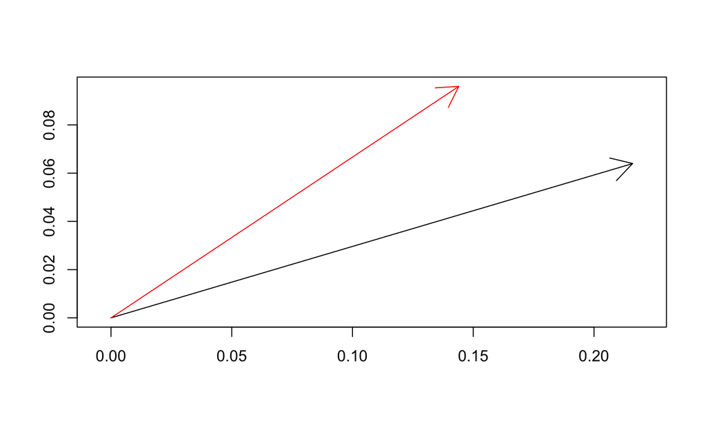

Le vecteur \(\mathbf{v_0}\) dont le carré de la norme est \({\mathbb E}({S}_{n}^{0})\) est en noir.

Le vecteur \(\mathbf{v_2}\) dont le carré de la norme est \(\frac{2}{n(n-1)}{\mathbb E}({S}_{n}^{2})\) est en rouge.

## Cauchy-Schwarz

Le produit scalaire est inférieur au produit des normes des vecteurs. La relation reste valide au carré:

\[\left[ \sum_s{p_s(1-p_s)^{n-1}} \right]^2 \le \left[ \sum_s{(1-p_s)^n} \right] \left[ \sum_s{p_s^2(1-p_s)^{n-2}} \right]\]

En substituant les espérances et en réarrangeant:

\[{\mathbb E}({S}_{n}^{0}) \ge \frac{n-1}{n}\frac{\left[ {\mathbb E}({S}_{n}^{1}) \right]^2}{2 {\mathbb E}({S}_{n}^{2})}\]

## Estimateur

L’estimateur est obtenu en remplaçant les espérances par les valeurs observées:

\[ {\hat{S}}_\mathit{Chao1} = {s}_{obs} + \frac{\left(n-1 \right){\left({s}_{n}^{1}\right)}^2}{2n{{s}_{n}^{2}}}\]

## Usage

Il s’agit d’un estimateur minimum : l’espérance du nombre d’espèces est supérieure ou égale au nombre estimé.

L’estimation est bonne tant que l’inventaire n’est pas trop sous-échantillonné.

Règle empirique (Brose, Martinez, and Williams 2003) : pas plus d’un tiers des espèces observées une seule fois. Au-delà: sous estimation importante.

## Application

## Simulation d’un inventaire

Communauté log-normale de 500 espèces, comparable à la forêt de Paracou. Echantillon de 4000 arbres (6 ha de forêt).

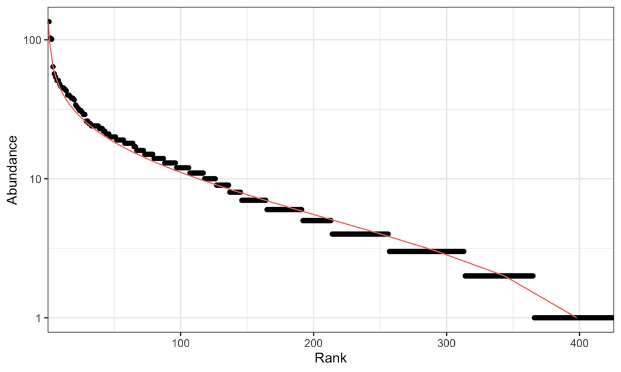

## Estimation

Nombre d’espèces observées : 426,

dont singletons : 61,

et doubletons : 52.

Estimateur Chao1 : 462 espèces.

## Test de l’estimateur

Simulation d’un grand nombre d’inventaires (10000) et estimation de la richesse à chaque simulation.

Le biais \(b\) est l’écart entre l’estimation moyenne et la vraie valeur : **-21** espèces.

La variance empirique de l’estimateur est \(\sigma^2\). L’erreur moyenne attendue de l’estimateur est \(\sqrt{b^2+\sigma^2}\), exprimée en pourcentage de la valeur réelle : **5%**.

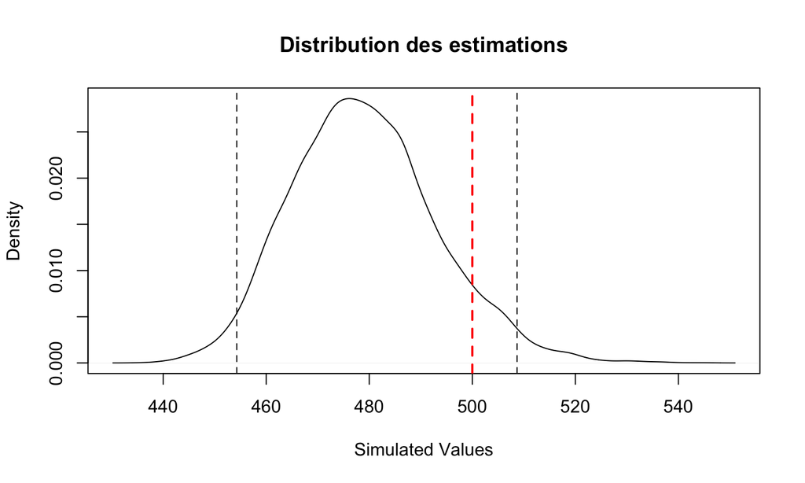

## Sous-échantillonnage

En limitant l’inventaire 600 arbres, environ 1 ha, la sous-estimation devient forte.

L’erreur moyenne est maintenant : **26%**.

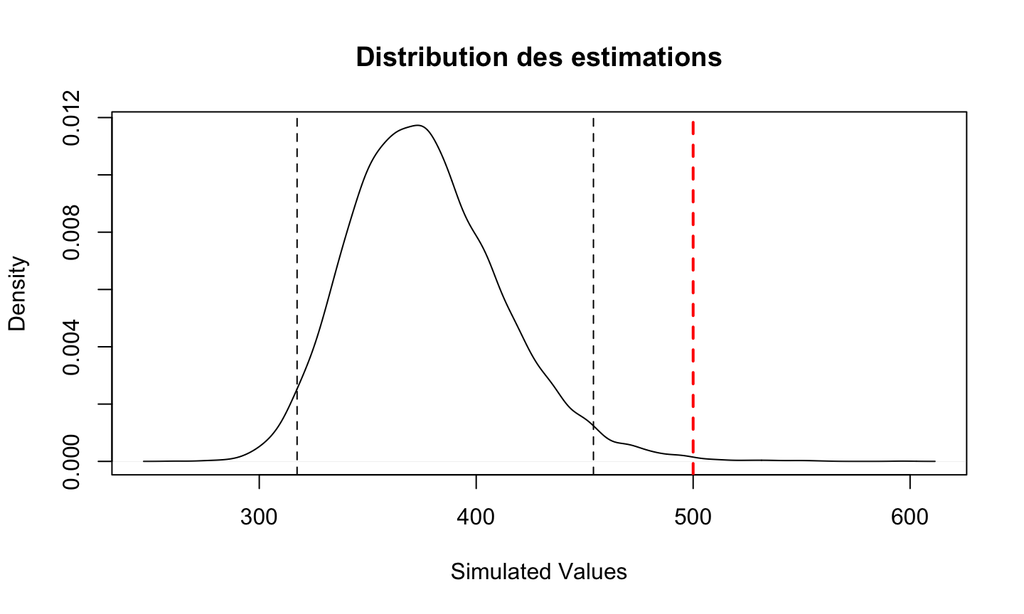

## Et Paracou ?

6,25 ha inventoriés, environ 4000 arbres.

Le nombre d’espèces observées est 334, dont 98 singletons.

L’estimateur Chao1 donne 415 espèces.

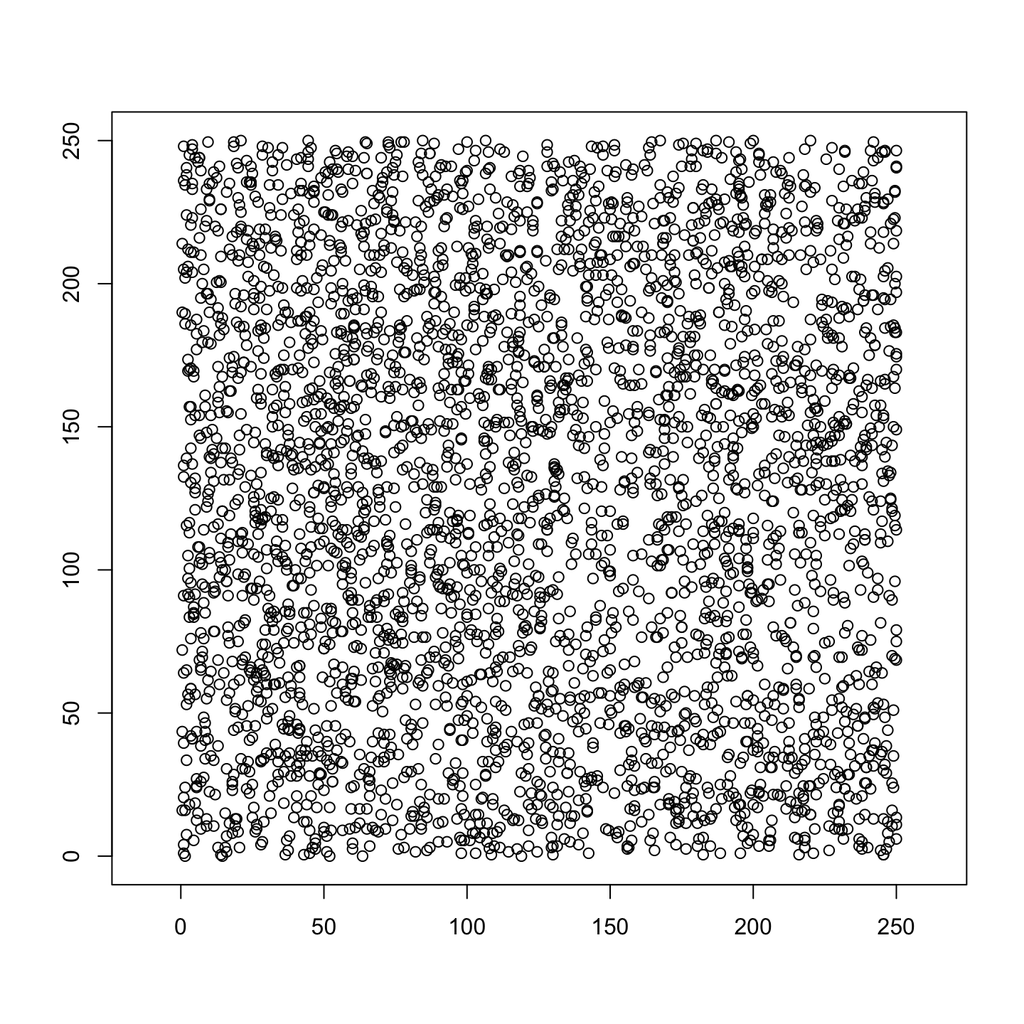

## Conclusion

L’estimation de la richesse à partir d’un échantillon est possible sans faire aucune supposition sur la distribution des probabilités.

Les estimateurs de ce type sont dits “non-paramétriques”. Ils sont bien supérieurs aux autres approches (estimateurs paramétriques ou extrapolation de la courbe aire-espèce).

L’estimateur de Chao est le plus connu. Il est très efficace quand l’échantillonnage est suffisant (moins d’un tiers de singletons).

Pour en savoir plus : Mesures de la biodiversité (https://hal-agroparistech.archives-ouvertes.fr/cel-01205813)

## References

Ce document est entièrement reproductible grâce à [RMarkdown](https://rmarkdown.rstudio.com/). Son code source est hébergé sur GitHub : https://github.com/EricMarcon/Chao1.

Bibliographie :

Brose, Ulrich, Neo D. Martinez, and Richard J. Williams. 2003. “Estimating species richness: Sensitivity to sample coverage and insensitivity to spatial patterns.” *Ecology* 84 (9): 2364–77. https://doi.org/10.1890/02-0558.

Chao, Anne. 2004. “Species richness estimation.” In *Encyclopedia of Statistical Sciences*, edited by N Balakrishnan, C B Read, and B Vidakovic, 2nd ed. New York: Wiley.